# Tensornetrics - LNM

Sammie Lee

2025-03-03

## **Setup**

```r
#Use the following to download tensornetrics from Github
#remotes::install_github("ataraxiart/tensornetrics")

library(psych)
library(psychonetrics)
library(torch)
library(tensornetrics)
library(dplyr)
library(qgraph)
```

## **Latent Network Model**

#### **Brief Explanation of Latent Network Model**

A Latent Network Model is similar to a conventional SEM model, just that instead of modelling directional relationships between factors (latent variables), we allow factors to share partial correlations with one another by assuming a multivariate Gaussian distribution for factors.

**In the diagram below:**

1. The white circles are our latent variables/factors
   - Arrows between factors = Partial correlations between factors
2. The white squares are our observed variables (Like questions in a questionaire)
   - Arrows from factors to observed variables = Factor Loadings
3. The shaded circles are our residuals/component unexplained by latent variable
   - Arrows from residuals to observed variables = Residual Errors

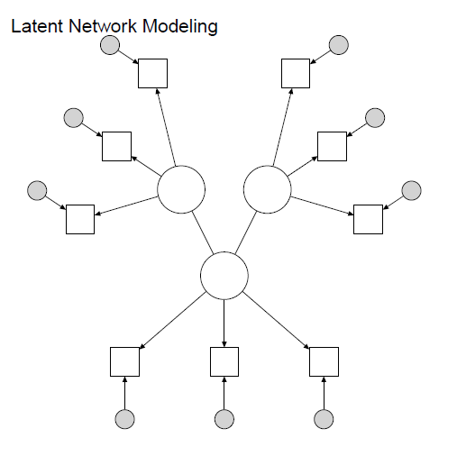

**The equation which models the covariance structure for the latent network model is as follows:**

$$\begin{equation}
\Sigma = \Lambda\Delta_\Psi(1 - \Omega_{\Psi})^{-1} \Delta_\Psi
\Lambda^\top + \Theta
\end{equation}$$

#### **Explanation of Matrices**

$\Sigma$ represents the model covariance matrix.

$\Lambda$ represents the factor loadings.

$\Omega_{\Psi}$ represents the partial correlations between the factors.

$\Theta$ represents the residual errors.

$\Delta_{\Psi}$ is a scaling matrix.

#### **What tensornetrics does w.r.t Latent Network Model**

##### **The `tensor_lnm` function**

The `tensor_lnm` function in `tensornetrics` fits a Latent Network Model to data obtained (i.e. from a questionaire) but first requires the user to specify a structure for the factor loadings. ($\Lambda$ Matrix)

Constraints on the partial correlations and residual errors can be specified but by default, it assumes all:

1. Partial correlations between latent variables are present
2. All residual errors for observed variables are present

`tensor_lnm` is similar to the `lnm` function in `psychonetrics` but uses a Gradient Descent method (Adam optimizer) in Torch to optimize the objective function instead of analytic gradients.

##### **Additional functionalities not found in `psychonetrics`**

`tensornetrics` also extends the functionalities of `psychonetrics` by allowing for the optimization of custom loss functions and LASSO to find non-zero partial correlations.

### **Concrete Example: Starwars Dataset and Factor Structure**

Our first dataset we will use for this demonstration is this `Starwars` questionaire found in `psychonetrics`. There are 10 questions about the Star Wars films measured on a 5-point Likert Scale and the proposed factor structure is shown below.

[figure not shown]

It is hypothesized that:

1. Love for Prequels affects responses for Q1, Q2, Q3, Q4
2. Love for Originals affects responses for Q1, Q5, Q6, Q7
3. Love for Sequels affects responses for Q1, Q8, Q9, Q10

We will proceed to load the data and specify the structure for the factor loadings.

```r
#Starwars dataset
data('StarWars')

#Get Design Matrix for lambda
lambda <- matrix(0, 10, 3)
lambda[1:4,1] <- 1
lambda[c(1,5:7),2] <- 1
lambda[c(1,8:10),3] <- 1

#Indicate names of observed and latent variables
observedvars <- colnames(StarWars[,1:10])
latents <- c('Prequels','Originals','Sequels')
```

### **Estimation of Model**

**To estimate a model using `tensor_lnm`, we feed the following arguments:**

1. data - dataframe of our questionaire
2. lambda - factor structure
3. vars - names of our observed variables
4. latents - names of our latent variables

**In the context of our `StarWars` example:**

1. data - `StarWars`
2. lambda - `lambda`
3. vars - `observedvars`
4. latents - `latents`

**To ensure uniqueness of the estimated model, there are 2 options:**

1. Setting variance of latent variables to be 1
2. Setting first factor loadings from each latent variable to be 1

**Fitting the model**

After instantiating the model using `tensor_lnm`, the `fit` method is called to fit the model to data.

```r
#2 ways of instantiating lnm module to ensure uniqueness of model


#Variance of latents set to 1
lnm <-  tensor_lnm(data=StarWars,lambda=lambda,vars = observedvars, latents= latents,device=torch_device('cpu'),
                   identification = "variance")

#Or alternatively identify via loadings, default is via variance
#first factor loading of each latent variable is set to 1

lnm <-  tensor_lnm(data=StarWars,lambda=lambda,vars = observedvars, latents= latents,device=torch_device('cpu'),
                   identification = "loadings")




#Fit using standard log-likelihood fit function
#Can adjust learning rate to your needs
lnm$fit(verbose = T, maxit = 5000, lr=0.05, tol = 1e-20)
```

[output not shown]

### **Get Partial Correlations, Factor Loadings and Residuals**

After fitting the model to data, we can obtain the partial correlations and their tests for significance using the method `get_partial_correlations`. If one just wants the partial correlations, they are stored in `lnm$omega_psi`.

```r
#Access partial correlations
lnm$get_partial_correlations()
```

```
##         Partial.Corr Standard.error P.value Significant
## Pre~Ori       -0.044          0.154  0.7770
## Pre~Seq        0.362          0.150  0.0161           *
## Ori~Seq        0.700          0.084  0.0000           *
```

We can visualize the partial correlations using the `qgraph` package:

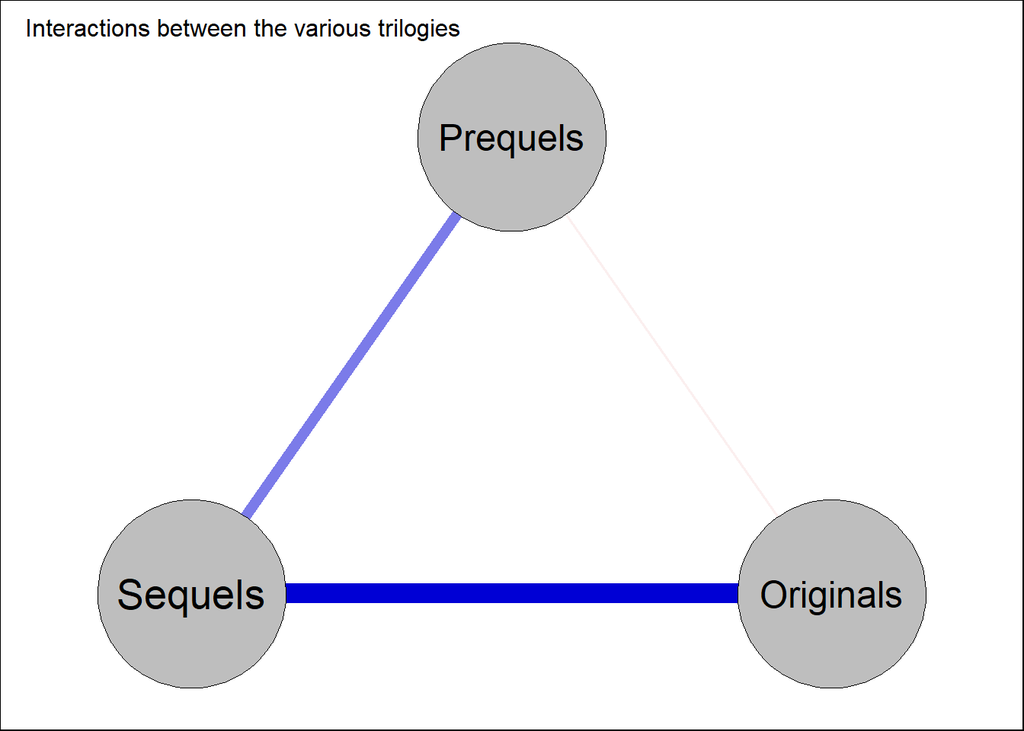

```r
qgraph(lnm$omega_psi,layout="circle",
       title="Interactions between the various trilogies",
       theme = "colorblind",
       labels = latents,
       vsize = 20,
       color = "gray",
       mar = rep(6,4))
box("figure")
```

We can access the factor loadings via `get_loadings()`.

```r
#Access factor loadings
lnm$get_loadings()
```

```
##         Factor.loadings Standard.error P.value Significant
## Q2~Pre            0.983          0.312  0.0016           *
## Q3~Pre            1.934          0.488  0.0001           *
## Q4~Pre           -1.461          0.422  0.0005           *
## Q5~Ori            0.926          0.259  0.0004           *
## Q6~Ori            1.608          0.432  0.0002           *
## Q7~Ori            1.109          0.300  0.0002           *
## Q8~Seq            2.147          0.837  0.0103           *
## Q9~Seq            0.324          0.211  0.1248
## Q10~Seq           1.581          0.642  0.0137           *
```

We can access the residual errors via `get_residuals()`.

```r
#Access residuals
lnm$get_residuals()
```

```
##     Residuals Standard.error P.value Significant
## Q1      0.945          0.083       0           *
## Q2      1.194          0.080       0           *
## Q3      0.913          0.102       0           *
## Q4      1.291          0.099       0           *
## Q5      1.110          0.074       0           *
## Q6      0.497          0.068       0           *
## Q7      1.041          0.073       0           *
## Q8      1.241          0.111       0           *
## Q9      1.057          0.065       0           *
## Q10     0.688          0.063       0           *
```

### **Stepwise Criterion Optimization**

Similar to `psychonetrics`, we can also select for partial correlations to leave in our model using stepwise procedures.

1. `stepdown` at each iteration removes one partial correlation which results in the biggest improvement in criterion until the criterion chosen does not improve
2. `stepup` at each iteration adds one partial correlation which results in the biggest improvement in criterion until the criterion chosen does not improve

```r
#Perform stepwise procedures, takes a while!
#Use tensornetrics:: to avoid clash issues with psychonetrics
stepdown_model <- stepdown(lnm,criterion='BIC')
final_model <- stepdown_model %>% stepup(criterion = 'BIC')
```

Again, we view the partial correlations of our final model and view some fit metrics.

```r
#View partial correlations of stepup_model

final_model$get_partial_correlations()
```

```
##         Partial.Corr Standard.error P.value Significant
## Pre~Seq        0.317          0.075       0           *
## Ori~Seq        0.697          0.066       0           *
```

```r
#Get fit metrics of final model:

final_model$get_fit_metrics()
```

```
##            Metrics     Values
## 1              CFI 0.97874582
## 2              TLI 0.96914721
## 3            RMSEA 0.03105444
## 4 RMSEA.lower.0.05 0.00000000
## 5 RMSEA.upper.0.95 0.05494085
```

### **Concrete Example 2: BFI Dataset**

Our second dataset we will use for this demonstration is this `bfi` questionaire found in the `psych` package. There are 25 questions about the Big-5 aspects of personality measured on a 5-point Likert Scale and the proposed factor structure is shown below.

We will use this dataset to showcase some functionalities which `tensornetrics` adds to the `psychonetrics` package.

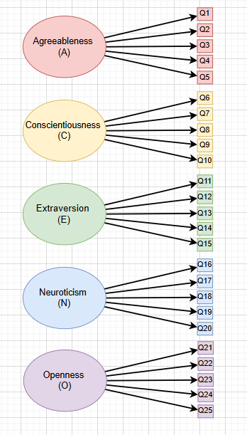

It is hypothesized that:

1. Agreeableness affects responses for Q1 - Q5
2. Conscientiousness affects responses for Q6 - Q10
3. Extraversion affects responses for Q11 - Q15
4. Neuroticism affects responses for Q16 - Q20
5. Openness affects responses for Q21 - Q25

We will proceed to load the data and specify the structure for the factor loadings.

```r
#bfi dataset

lambda <- matrix(0, 25, 5)
lambda[1:5,1] <- 1
lambda[6:10,2] <- 1
lambda[11:15,3] <- 1
lambda[16:20,4] <- 1
lambda[21:25,5] <- 1

latents <- c('Agreeableness','Conscientiousness','Extraversion','Neuroticism','Openness')
observedvars <- colnames(bfi)[1:25]
```

### **Custom Loss Function**

Instead of using the default loss function based on log-likelihood used customarily for SEM models, we can also define our custom loss function to minimize for the estimation of parameters in the model.

One loss function other than the one based on log-likelihood is the **LAD (Least Absolute Deviation) Estimator** with the following functional form:

$$\begin{align*}
&\text{Denote $n$ by $n$ model covariance matrix (with parameter
$\theta$) as: } \Sigma(\theta) \\
&\text{Denote $n$ by $n$ empirical covariance matrix as: } S \\
&\text{LAD estimator is then} \sum_{i = 1}^n \sum_{j = 1}^n
|\Sigma(\theta)_{ij} - S_{ij}|
\end{align*}$$

One application of the LAD estimator is the robust estimation of parameters due to outliers. Custom loss functions for `tensornetrics` must have 2 arguments - the model covariance matrix `Sigma` and our observed data `data`. We can define the LAD estimator and feed it into our `tensor_lnm` function. The procedure for estimation is the same as before just that we use `custom_fit` instead.

```r
# Example Code to show the use of a custom loss function
# We define a custom loss function, LAD estimator with inputs, sigma
#(the model covariance matrix) and mod (the lnm module to access its sample covariance attribute)

lad_estimator <- function(sigma, data){
  get_cov_matrix <- function(data) {
    data_matrix <- as_array(data)
    if (!is.null(data_matrix )) {
      return(cov(data_matrix , use = "pairwise.complete.obs"))  # Handles NAs if present
    } else {
      stop("data_matrix is NULL")
    }
  }
  cov_matrix <- get_cov_matrix(data)
  torch_sum(torch_abs(sigma - cov_matrix))
}

lnm_custom <-  tensor_lnm(data=bfi%>%na.omit(),lambda=lambda,vars = observedvars, latents= latents,device=torch_device('cpu'),
                   custom_loss = lad_estimator)

lnm_custom$custom_fit(verbose = FALSE)
lnm_custom$get_partial_correlations()
```

```
##         Partial.Corr
## Agr~Con        0.107
## Agr~Ext        0.556
## Agr~Neu       -0.003
## Agr~Ope        0.022
## Con~Ext        0.141
## Con~Neu       -0.272
## Con~Ope        0.111
## Ext~Neu       -0.135
## Ext~Ope        0.258
## Neu~Ope        0.010
```

### **LASSO**

Lastly, instead of using stepwise procedures to select which partial correlations to leave inside our model, we can also apply LASSO to select the partial correlations for us.

**To do this:**

1. We instantiate an LNM model using `tensor_lnm` but set `lasso = TRUE`
2. We use the `lasso_explore` function, specifying the range of hyperparameter values `v_values` to explore and this returns an R list which contains

-The optimal hyperparameter $v$ value

-Partial Correlations to set to zero

3. We refit the model found by `lasso_explore` by specifying which partial correlations to set to zero inside `omega_psi_constraint_lst`

```r
#Using LASSO to select for pairs of latent variables to include in our network

#Instantiate an lnm module but set lasso to TRUE
lnm_lasso <- tensor_lnm(data=bfi%>%na.omit(),lasso=TRUE,lambda=lambda,vars = observedvars, latents= latents,device=torch_device('cpu'))

#We use lasso_explore to perform lasso
#By default algo chooses among 30 values from 0.01 to 100 on a logscale
#We set cutoff for partial correlations to be 0.0001
optimal_parameter <- lasso_explore(lnm_lasso,epsilon = 0.0001,v_values = pracma::logspace(log10(100), log10(10000), 30))


#Here, we get a list containing value of v selected and the constraints for omega_psi
print(optimal_parameter)
```

```
## $penalty_parameter
## [1] 161.0262
##
## $omega_psi_constraints
## $omega_psi_constraints$rows
## [1] 5
##
## $omega_psi_constraints$cols
## [1] 4
##
## $omega_psi_constraints$values
## [1] 0
```

```r
#Fit the model selected by lasso by substituting in the constraints
lnm_lasso <- tensor_lnm(data=bfi%>%na.omit(),lasso=F,lambda=lambda,vars = observedvars, latents= latents,device=torch_device('cpu'),
                        omega_psi_constraint_lst = optimal_parameter[[2]],identification = 'variance')
lnm_lasso$fit(verbose = FALSE)

#partial correlations of new model
lnm_lasso$get_partial_correlations()
```

```
##         Partial.Corr Standard.error P.value Significant
## Agr~Con       -0.095          0.026  0.0003           *
## Agr~Ext        0.667          0.016  0.0000           *
## Agr~Neu       -0.048          0.023  0.0404           *
## Agr~Ope        0.113          0.029  0.0001           *
## Con~Ext       -0.114          0.027  0.0000           *
## Con~Neu        0.207          0.019  0.0000           *
## Con~Ope        0.151          0.024  0.0000           *
## Ext~Neu       -0.066          0.022  0.0029           *
## Ext~Ope       -0.366          0.026  0.0000           *
```

We can further remove the insignificant partial correlations (if any) via the `prune` function in `tensornetrics`.

```r
#We can remove the insignificant partial correlations via the prune function
lnm_lasso <- tensornetrics::prune(lnm_lasso)
lnm_lasso$get_partial_correlations()
```

```
##         Partial.Corr Standard.error P.value Significant
## Agr~Con       -0.095          0.026  0.0003           *
## Agr~Ext        0.667          0.016  0.0000           *
## Agr~Neu       -0.048          0.023  0.0404           *
## Agr~Ope        0.113          0.029  0.0001           *
## Con~Ext       -0.114          0.027  0.0000           *
## Con~Neu        0.207          0.019  0.0000           *
## Con~Ope        0.151          0.024  0.0000           *
## Ext~Neu       -0.066          0.022  0.0029           *
## Ext~Ope       -0.366          0.026  0.0000           *
```

We visualize the interactions between the latent variables via the `qgraph` package:

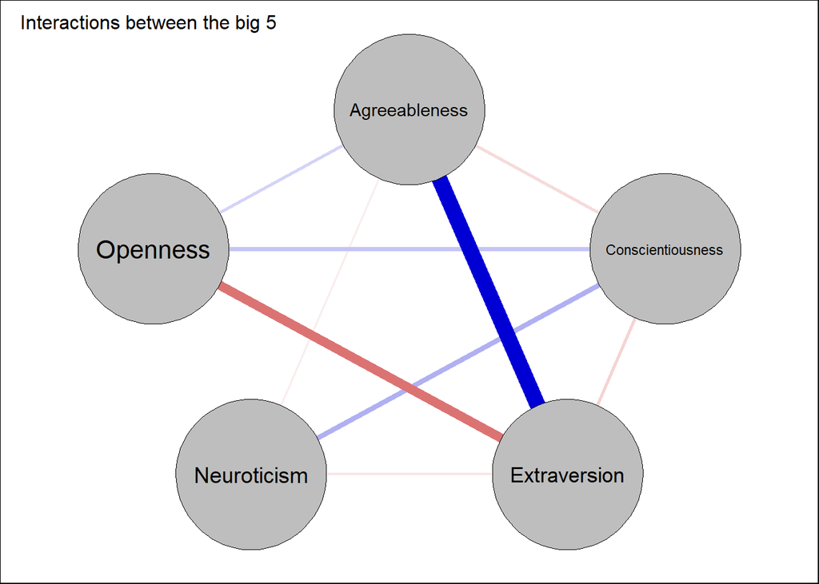

```r
qgraph(lnm_lasso$omega_psi,layout="circle",
       title="Interactions between the big 5",
       theme = "colorblind",
       labels = latents,
       vsize = 20,
       color = "gray",
       mar = rep(6,4))
box("figure")
```

We finally get some fit metrics:

```r
#Get fit metrics for model obtained after lasso
lnm_lasso$get_fit_metrics()
```

```
##            Metrics     Values
## 1              CFI 0.77880883
## 2              TLI 0.75053626
## 3            RMSEA 0.07776187
## 4 RMSEA.lower.0.05 0.07557717
## 5 RMSEA.upper.0.95 0.07992233
```